# Assignment 2: Math1312: Regression Analysis

Rupesh Papneja, s3637387

April 17, 2019

# Experiment: Drugs retained in liver

An experiment was conducted to investigate the amount of drug retained in the liver of a rat. The data about the experiment contains 19 records.

## Insights

The dataset contains the below fields:

- Y - is the dependent variable, which is amount of drug retained in the liver
- Dose
- LvrWt - liver weight
- BdyWt - body weight

The data is loaded into the dataframe.

```r
df <- readxl::read_excel('liver.xlsx')
head(df, 5) %>%
  kable(., caption = "Table 1: First five records from the dataset") %>%
  kable_styling()
```

Table 1: First five records from the dataset

| BdyWt | LvrWt | Dose | Y |
| --- | --- | --- | --- |
| 176 | 6.5 | 0.88 | 0.42 |
| 176 | 9.5 | 0.88 | 0.25 |
| 190 | 9.0 | 1.00 | 0.56 |
| 176 | 8.9 | 0.88 | 0.23 |
| 200 | 7.2 | 1.00 | 0.23 |

The data is plotted below. The plot below provides the below details.

- Correlation coefficient (r)
- Histogram with density estimation and rug plot.
- Scatter plot with fitted line

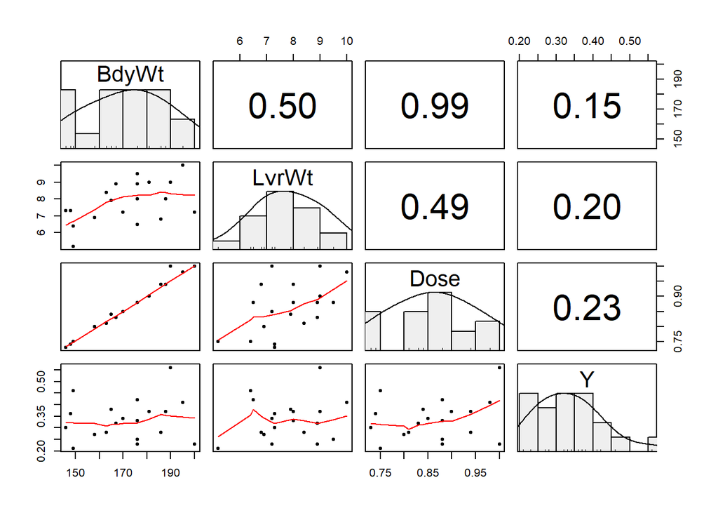

Figure 1: Scatter matrix plot for the experiment data.

```r
pairs.panels(df,
             method = "pearson", # correlation method
             hist.col = "#efefef",
             density = TRUE,  # show density plots
             ellipses = FALSE, # show correlation ellipses
             lm = FALSE, cor = TRUE
             )
```

From the plot above, we can infer the following:

- There is very strong correlation between dose and body weight fields.
- Most of the independent variables appear to follow normal distribution.
- There is some correlation between liver weight and other two atrributes body weight and dose.
- There may be some multicollinearity present in the dataset.

### Multiple Linear regression model

To enable further analysis, a multiple linear regression model is created.

```r
lm.model_1 <- lm(Y~BdyWt+LvrWt+Dose, data = df)
summary_lm.model_1 <- summary(lm.model_1)
summary_lm.model_1
```

```
##
## Call:
## lm(formula = Y ~ BdyWt + LvrWt + Dose, data = df)
##
## Residuals:
##       Min        1Q    Median        3Q       Max
## -0.100557 -0.063233  0.007131  0.045971  0.134691
##
## Coefficients:
##              Estimate Std. Error t value Pr(>|t|)
## (Intercept)  0.265922   0.194585   1.367   0.1919
## BdyWt       -0.021246   0.007974  -2.664   0.0177 *
## LvrWt        0.014298   0.017217   0.830   0.4193
## Dose         4.178111   1.522625   2.744   0.0151 *
## ---
## Signif. codes:  0 '***' 0.001 '**' 0.01 '*' 0.05 '.' 0.1 ' ' 1
##
## Residual standard error: 0.07729 on 15 degrees of freedom
## Multiple R-squared:  0.3639, Adjusted R-squared:  0.2367
## F-statistic:  2.86 on 3 and 15 DF,  p-value: 0.07197
```

*The model is not significant at 95% level of significance with p-value 0.0719701 > 0.05. The Intercept and Coefficient for liver weight are also not significant.*

*The adjusted ${R}^2$ value 0.236685 is low, which means that only 23.67 % observed variation is explained by the linear model.*

## Calulating the design matrix

The design matrix C = ${({X^TX})^{-1}}$, where $X$ is the model matrix.

The model matrix can be retrieved from linear model or can also be created from the dataset.

```r
mm <- model.matrix(lm.model_1) # model matrix from model
head(mm)  %>%
  kable(., caption = "Table 2: Model Matrix") %>%
  kable_styling()
```

Table 2: Model Matrix

| (Intercept) | BdyWt | LvrWt | Dose |
| --- | --- | --- | --- |
| 1 | 176 | 6.5 | 0.88 |
| 1 | 176 | 9.5 | 0.88 |
| 1 | 190 | 9.0 | 1.00 |
| 1 | 176 | 8.9 | 0.88 |
| 1 | 200 | 7.2 | 1.00 |
| 1 | 167 | 8.9 | 0.83 |

```r
X <- as.matrix(cbind(rep(1, nrow(df)), df$BdyWt, df$LvrWt, df$Dose)) # model matrix using dataset
```

Calculation for design matrix is given below.

```r
n <- nrow(df) # number of rows
nr <- ncol(df) - 1
p <- length(coef(lm.model_1))
y <- df$Y

C <- solve(t(X) %*% X) # solve function is standard r function for inverse of matrix
C %>%
  kable(., caption = "Table 3: Design Matrix") %>%
  kable_styling()
```

Table 3: Design Matrix

| 6.3380938 | -0.0744270 | -0.0680054 | 8.133435 |
| --- | --- | --- | --- |
| -0.0744270 | 0.0106445 | -0.0027837 | -2.006297 |
| -0.0680054 | -0.0027837 | 0.0496205 | 0.183175 |
| 8.1334355 | -2.0062967 | 0.1831750 | 388.083185 |

## Equation of best fit

The equation for fitted values can be written as $\hat{Y}$ = ${X}{\hat{\beta}}$, where ${\hat{\beta}}$ = ${({X^TX})^{-1}}{X}^T{Y}$.

residuals are ${e}$ = ${Y}$ - $\hat{Y}$

Below calculations are done for fitted values, and coefficients and the residuals.

```r
beta_hat <- solve(t(X) %*% X) %*% t(X) %*% y
coefs <- as.vector(beta_hat[,1])
y_hat <- X %*% solve(t(X) %*% X) %*% t(X) %*% y
e <- y - y_hat
sigma <- sqrt(t(e) %*% e / (n - p))
```

Therefore, equation for best fit is **$\hat{Y}$: 0.2659217 - 0.0212463${X_1}$ + 0.0142981${X_2}$ + 4.178111${X_3}$**

## ANOVA

Analysis of Variance (ANOVA) consists of calculations that provide information about levels of variability within a regression model and form a basis for tests of significance.

Given below is analysis of variance table for the model.

```r
anova_1 <- car::Anova(lm.model_1, type="III")
anova_1
```

```
## Anova Table (Type III tests)
##
## Response: Y
##               Sum Sq Df F value  Pr(>F)
## (Intercept) 0.011157  1  1.8676 0.19188
## BdyWt       0.042408  1  7.0988 0.01768 *
## LvrWt       0.004120  1  0.6897 0.41930
## Dose        0.044982  1  7.5296 0.01507 *
## Residuals   0.089609 15
## ---
## Signif. codes:  0 '***' 0.001 '**' 0.01 '*' 0.05 '.' 0.1 ' ' 1
```

*From the ANOVA table, for liver weight the P-value for the F test statistic is greater than 0.05, providing strong evidence for the null hypothesis that ${\beta}_i$ = 0, which can further inferred to say that model is not adequate.*

*Further the ${R}^2$ value 0.3639041 is low, which means that the only 36.39 % observed variation is explained by the linear model.*

Further hypothesis testing can be performed to support the conclusions above.

## Hypothesis testing

### Significance of regression test

In multiple regression, the significance of regression test is

${H_0}$ : ${\beta_1}$ $=$ ${\beta_2}$ ${=}$ ${\beta_3}$ $=$ 0

The alternative hypothesis here is

${H_a}$ : ${\beta_i}$ $\ne$ 0 for atleast one $i$, where $i$ = 1,2..3

Below given is the calculation of F test statistic, which will be used to test the hypothesis.

${F}$ = $\frac{{\sum_{i=1}^n}({\hat{Y}_{1i}} - {\bar{Y}})^2/(p-1)}{{\sum_{i=1}^n}(Y_i - \hat{Y}_{1i})^2/(n-p)}$

Decision: Reject ${H_0}$, if ${F_0}$ > ${F_{p-1,n-p,\alpha}}$, where $\alpha$ = 0.05

```r
an <- anova(lm.model_1)
SSR <- an$`Sum Sq`
SSE <- SSR[p]
SSR <- SSR[1:nr]
DF <- an$Df
F0 <- (sum(SSR)/sum(DF[1:nr])) / (SSE/DF[p])
F_CRIT <- qf(df1 = sum(DF[1:nr]), df2 = (n - p), p = 0.95)
```

Since **${F_0}$ : 2.8604505 < ${F_{3,15,.95}}$ : 3.2873821**, We **fail to reject** the null hypothesis that at ${\alpha}$ = 0.5, and can conclude that **all of ${\beta}_s$ are equal to 0**.

### Tests on individual regression coefficients

For tests on individual regression coefficients,

${H_0}$ : ${\beta_i}$ $=$ 0

${H_a}$ : ${\beta_i}$ $\ne$ 0, where $i$ = 1,2..3

Here T test statistic is calculated as,

${t}$ = $\frac{\hat{\beta}_{j} - {\beta}_{j}}{SE[\hat{\beta}_{j}]}$ = $\frac{\hat{\beta}_{j} - 0}{s_e{\sqrt{C_{jj}}}}$

Decision: Reject ${H_0}$, if ${t_0}$ > ${t_{n-p-1,\alpha/2}}$ , where $\alpha$ = 0.05

```r
t_stats_1 <- abs((coefs[2] - 0)/sigma * sqrt(C[2,2]))
t_stats_2 <- abs((coefs[3] - 0)/sigma * sqrt(C[3,3]))
t_stats_3 <- abs((coefs[4] - 0)/sigma * sqrt(C[4,4]))
T_CRIT <- qt(p = 0.975, df = n - nr - 1)
```

For $\beta_2$

## Correlation and Variance of inflation factor

### Correlation

Given below is the correlation matrix for independent variables and a correlation plot.

```r
cor(df[,1:3], method = c("pearson")) %>%
  kable(., caption = "Table 4: Correlation matrix") %>%
  kable_styling()
```

Table 4: Correlation matrix

|  | BdyWt | LvrWt | Dose |
| --- | --- | --- | --- |
| BdyWt | 1.0000000 | 0.5000101 | 0.9902126 |
| LvrWt | 0.5000101 | 1.0000000 | 0.4900711 |
| Dose | 0.9902126 | 0.4900711 | 1.0000000 |

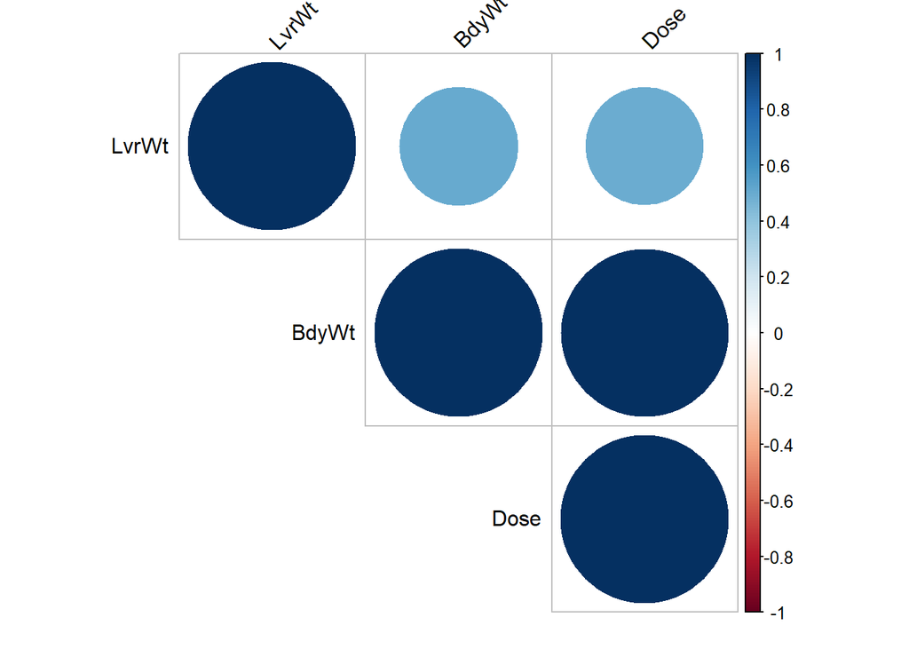

Figure 2: Correlation plot

```r
corrplot::corrplot(cor(df[,1:3], method = c("pearson")), type = "upper", order = "hclust",
         tl.col = "black", tl.srt = 45)
```

*From the correlation matrix and plot we can see that body weight and dose are highly postively correlated. There is be some positive correlation between liver weight and other predictors body weight and dose.*

### Variance of inflation factor

Given below is VIF for the regression model.

```r
car::vif(lm.model_1) %>%
  kable(., caption = "Table 5: Variance of inflation factor") %>%
  kable_styling()
```

Table 5: Variance of inflation factor

|  | x |
| --- | --- |
| BdyWt | 52.101912 |
| LvrWt | 1.335679 |
| Dose | 51.427147 |

```r
sqrt(car::vif(lm.model_1)) > 2.24
```

```
## BdyWt LvrWt  Dose
##  TRUE FALSE  TRUE
```

*We see that VIF is greater than 5, even 10 for body weight and dose, which indicates **high multicollinearity** present in the model due Body weight and Dose.*

## Backward Elimination

Backward Elimination starts with all predictors in the model, iteratively removes the least contributive predictors, and stops when you have a model where all predictors are statistically significant.

To perform the backward elimination, a model with all the predictors is created. A null model is also created to check if any of the predictors are useful.

```r
full_model_1 <- lm(Y~BdyWt+LvrWt+Dose, data = df)
null_model_1 <- lm(Y~1, data = df)
```

Then anova() is then used to compare the models. Given below are the results.

```r
anova_compare <- anova(null_model_1,full_model_1)
acp_v <- anova_compare$`Pr(>F)`
acf_v <- anova_compare$`F`
anova_compare
```

```
## Analysis of Variance Table
##
## Model 1: Y ~ 1
## Model 2: Y ~ BdyWt + LvrWt + Dose
##   Res.Df      RSS Df Sum of Sq      F  Pr(>F)
## 1     18 0.140874
## 2     15 0.089609  3  0.051265 2.8605 0.07197 .
## ---
## Signif. codes:  0 '***' 0.001 '**' 0.01 '*' 0.05 '.' 0.1 ' ' 1
```

Given below is the summary of full model

```r
summary(full_model_1)
```

```
##
## Call:
## lm(formula = Y ~ BdyWt + LvrWt + Dose, data = df)
##
## Residuals:
##       Min        1Q    Median        3Q       Max
## -0.100557 -0.063233  0.007131  0.045971  0.134691
##
## Coefficients:
##              Estimate Std. Error t value Pr(>|t|)
## (Intercept)  0.265922   0.194585   1.367   0.1919
## BdyWt       -0.021246   0.007974  -2.664   0.0177 *
## LvrWt        0.014298   0.017217   0.830   0.4193
## Dose         4.178111   1.522625   2.744   0.0151 *
## ---
## Signif. codes:  0 '***' 0.001 '**' 0.01 '*' 0.05 '.' 0.1 ' ' 1
##
## Residual standard error: 0.07729 on 15 degrees of freedom
## Multiple R-squared:  0.3639, Adjusted R-squared:  0.2367
## F-statistic:  2.86 on 3 and 15 DF,  p-value: 0.07197
```

It can be observed that not all predictors are significant.

Next list of models with combination of two predictors are created.

```r
small_model_1_d <- lm(Y~BdyWt+LvrWt, data = df)
small_model_1_l <- lm(Y~BdyWt+Dose, data = df)
small_model_1_b <- lm(Y~LvrWt+Dose, data = df)
```

Summary of model with Body weight and Liver weight is given below.

```r
summary(small_model_1_d)
```

```
##
## Call:
## lm(formula = Y ~ BdyWt + LvrWt, data = df)
##
## Residuals:
##      Min       1Q   Median       3Q      Max
## -0.12027 -0.05439 -0.00918  0.03940  0.20355
##
## Coefficients:
##              Estimate Std. Error t value Pr(>|t|)
## (Intercept) 0.1783570  0.2277755   0.783    0.445
## BdyWt       0.0003535  0.0015138   0.234    0.818
## LvrWt       0.0123260  0.0204127   0.604    0.554
##
## Residual standard error: 0.09172 on 16 degrees of freedom
## Multiple R-squared:  0.0446, Adjusted R-squared:  -0.07483
## F-statistic: 0.3735 on 2 and 16 DF,  p-value: 0.6942
```

It is observed that none of the predictors are significant.

The summary of next model with predictors body weight and dose is given below.

```r
summary(small_model_1_l)
```

```
##
## Call:
## lm(formula = Y ~ BdyWt + Dose, data = df)
##
## Residuals:
##      Min       1Q   Median       3Q      Max
## -0.12333 -0.07416  0.01238  0.04884  0.12668
##
## Coefficients:
##              Estimate Std. Error t value Pr(>|t|)
## (Intercept)  0.285517   0.191267   1.493   0.1550
## BdyWt       -0.020444   0.007838  -2.608   0.0190 *
## Dose         4.125329   1.506472   2.738   0.0146 *
## ---
## Signif. codes:  0 '***' 0.001 '**' 0.01 '*' 0.05 '.' 0.1 ' ' 1
##
## Residual standard error: 0.07654 on 16 degrees of freedom
## Multiple R-squared:  0.3347, Adjusted R-squared:  0.2515
## F-statistic: 4.024 on 2 and 16 DF,  p-value: 0.0384
```

Similarly given below is the summary for the model with predictors liver weight and dose is given below.

```r
summary(small_model_1_b)
```

```
##
## Call:
## lm(formula = Y ~ LvrWt + Dose, data = df)
##
## Residuals:
##       Min        1Q    Median        3Q       Max
## -0.123858 -0.055661 -0.007873  0.041464  0.190407
##
## Coefficients:
##             Estimate Std. Error t value Pr(>|t|)
## (Intercept) 0.117366   0.219094   0.536    0.600
## LvrWt       0.008742   0.020085   0.435    0.669
## Dose        0.173550   0.286261   0.606    0.553
##
## Residual standard error: 0.09084 on 16 degrees of freedom
## Multiple R-squared:  0.06287,    Adjusted R-squared:  -0.05427
## F-statistic: 0.5367 on 2 and 16 DF,  p-value: 0.5948
```

**Comparing the models given above it can inferred that the model with predictors body weight and dose is best so far. The model is significant and except for intercept all the coefficients are significant.**

Since intercept is not significant, models with single predictors is also created and checked.

```r
vsmall_model_1_d <- lm(Y~Dose, data = df)
vsmall_model_1_l <- lm(Y~LvrWt, data = df)
vsmall_model_1_b <- lm(Y~BdyWt, data = df)
summary(vsmall_model_1_d)
```

```
##
## Call:
## lm(formula = Y ~ Dose, data = df)
##
## Residuals:
##      Min       1Q   Median       3Q      Max
## -0.13761 -0.06211 -0.00427  0.04850  0.19239
##
## Coefficients:
##             Estimate Std. Error t value Pr(>|t|)
## (Intercept)   0.1330     0.2109   0.631    0.537
## Dose          0.2346     0.2435   0.963    0.349
##
## Residual standard error: 0.08864 on 17 degrees of freedom
## Multiple R-squared:  0.05178,    Adjusted R-squared:  -0.004002
## F-statistic: 0.9283 on 1 and 17 DF,  p-value: 0.3488
```

```r
summary(vsmall_model_1_l)
```

```
##
## Call:
## lm(formula = Y ~ LvrWt, data = df)
##
## Residuals:
##      Min       1Q   Median       3Q      Max
## -0.12129 -0.05790 -0.00805  0.03739  0.20724
##
## Coefficients:
##             Estimate Std. Error t value Pr(>|t|)
## (Intercept)  0.22037    0.13573   1.624    0.123
## LvrWt        0.01471    0.01718   0.856    0.404
##
## Residual standard error: 0.08913 on 17 degrees of freedom
## Multiple R-squared:  0.04134,    Adjusted R-squared:  -0.01505
## F-statistic: 0.7331 on 1 and 17 DF,  p-value: 0.4038
```

```r
summary(vsmall_model_1_b)
```

```
##
## Call:
## lm(formula = Y ~ BdyWt, data = df)
##
## Residuals:
##       Min        1Q    Median        3Q       Max
## -0.128342 -0.060647 -0.008889  0.046916  0.209763
##
## Coefficients:
##              Estimate Std. Error t value Pr(>|t|)
## (Intercept) 0.1962346  0.2215825   0.886    0.388
## BdyWt       0.0008105  0.0012862   0.630    0.537
##
## Residual standard error: 0.08999 on 17 degrees of freedom
## Multiple R-squared:  0.02283,    Adjusted R-squared:  -0.03465
## F-statistic: 0.3971 on 1 and 17 DF,  p-value: 0.537
```

*Even after comparing with the models created with single predictors, it is observed that **the model with predictors body weight and dose** is the best one.*

But *body weight and dose* have high correlation, trying out with models with single predictors body weight and dose without intercept.

```r
summary(lm(Y~Dose -1, data = df))
```

```
##
## Call:
## lm(formula = Y ~ Dose - 1, data = df)
##
## Residuals:
##       Min        1Q    Median        3Q       Max
## -0.157455 -0.060277  0.005793  0.042416  0.172545
##
## Coefficients:
##      Estimate Std. Error t value Pr(>|t|)
## Dose  0.38745    0.02308   16.79 1.94e-12 ***
## ---
## Signif. codes:  0 '***' 0.001 '**' 0.01 '*' 0.05 '.' 0.1 ' ' 1
##
## Residual standard error: 0.08715 on 18 degrees of freedom
## Multiple R-squared:  0.9399, Adjusted R-squared:  0.9366
## F-statistic: 281.7 on 1 and 18 DF,  p-value: 1.936e-12
```

```r
summary(lm(Y~BdyWt -1, data = df))
```

```
##
## Call:
## lm(formula = Y ~ BdyWt - 1, data = df)
##
## Residuals:
##       Min        1Q    Median        3Q       Max
## -0.158931 -0.058505  0.004405  0.044962  0.190515
##
## Coefficients:
##        Estimate Std. Error t value Pr(>|t|)
## BdyWt 0.0019447  0.0001191   16.33  3.1e-12 ***
## ---
## Signif. codes:  0 '***' 0.001 '**' 0.01 '*' 0.05 '.' 0.1 ' ' 1
##
## Residual standard error: 0.08945 on 18 degrees of freedom
## Multiple R-squared:  0.9367, Adjusted R-squared:  0.9332
## F-statistic: 266.5 on 1 and 18 DF,  p-value: 3.098e-12
```

*The above two models are better than the all the other models. The models are significant and the individual coefficients are also significant.*

*Between the above two models, model with single predictor as Dose is better than the one with Body weight as Standard error and the p-value are less for model. The adjusted $R^2$ are similar.*

**Hence to conclude, using Backward elimination, the best model is with single predictor Dose.**

Given below is the diagonistic for the model selected above.

In regression the following assumptions are made about residuals:

- The residuals have normal distribution.
- have mean zero.
- have same but unknown variance (homoscedasticity).
- are independent of each other (independent).

The plot for residuals is given below.

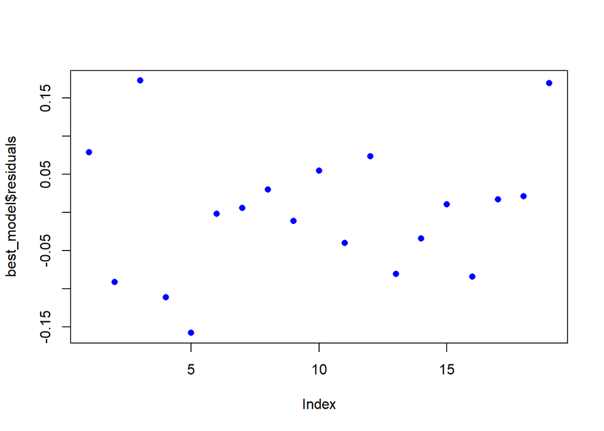

Figure 4: Residual plot for best model

```r
best_model <- lm(Y~Dose -1, data = df)
plot(best_model$residuals, pch=16, col="blue")
```

There is no pattern observed in the plot, hence residuals are independent of each other.

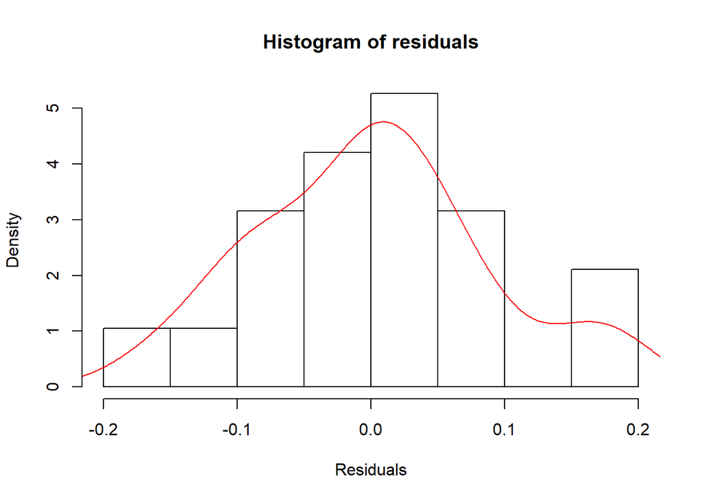

Figure 5: Histogram of residuals

```r
hist(best_model$residuals,probability=T, main="Histogram of residuals",xlab="Residuals")
lines(density(best_model$residuals),col=2)
```

*The histogram does not clealy that the residuals are normal. Since the data set is small, it cannot be clearly concluded if the residuals are normal or not.*

Below given is the histogram or standardized residuals.

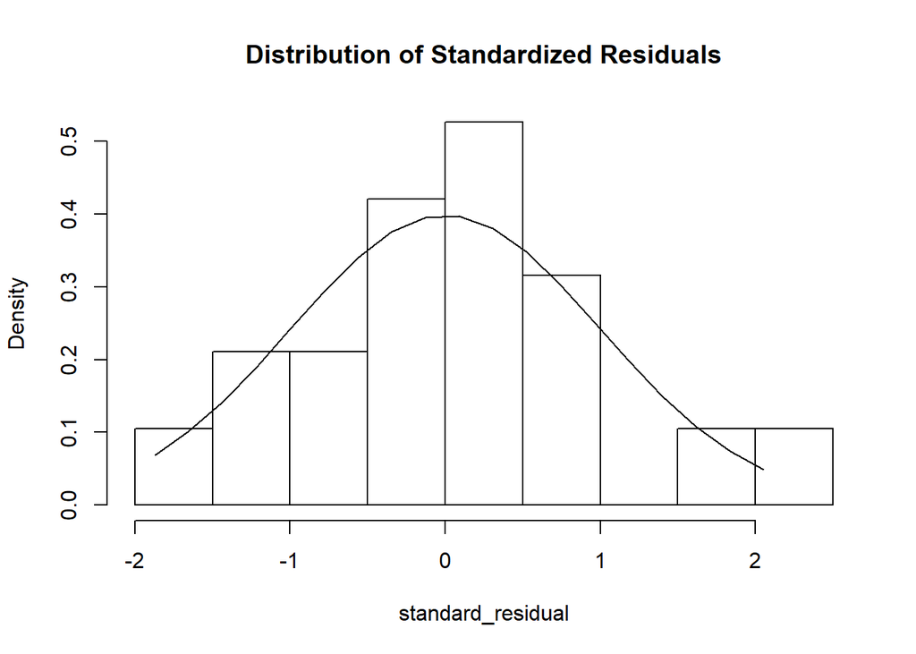

Figure 6: Histogram of standardized residuals

```r
standard_residual <- rstandard(best_model)
hist(standard_residual, freq=FALSE,
main="Distribution of Standardized Residuals")
xp<-seq(min(standard_residual),max(standard_residual),length=n)
yp<-dnorm(xp)
lines(xp, yp)
```

*The plot is better than the previous plot and show that residuals may be normal.*

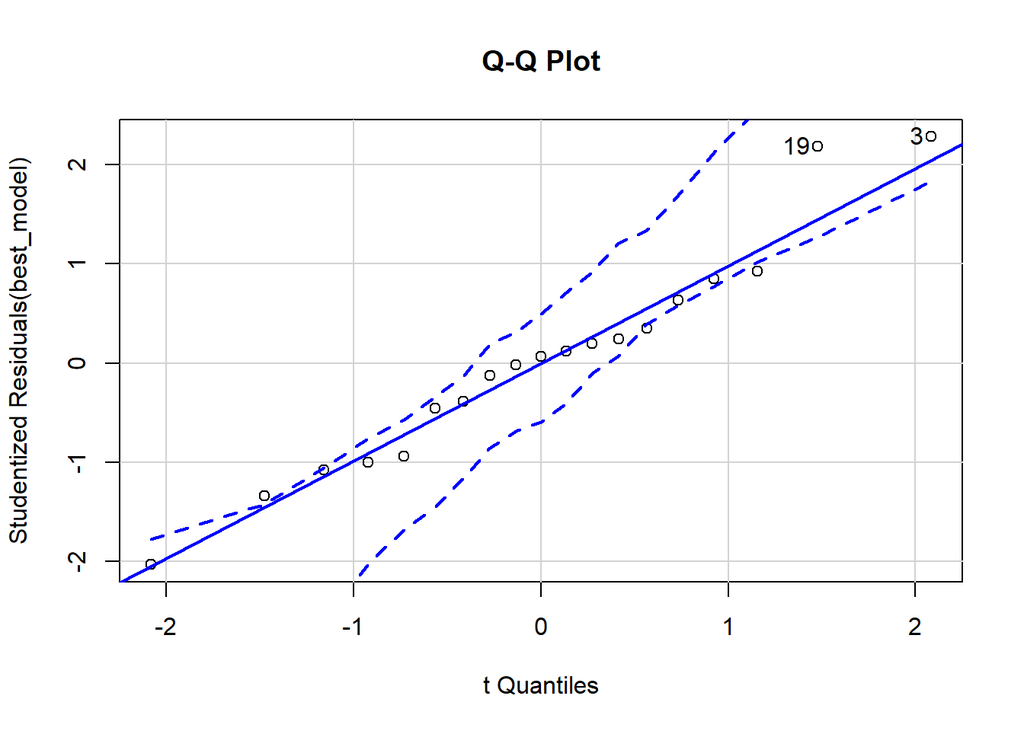

Figure 7: QQPlot for Residuals

```r
qq <- qqPlot(best_model,simulate = T, main = "Q-Q Plot")
```

*Same normality assumption can be made from Q-Q plot of the residuals, but it also shows some outliers.*

Below tests are performed to check autocorrelation and normailty for residuals.

```r
durbinWatsonTest(best_model)
```

```
##  lag Autocorrelation D-W Statistic p-value
##    1       -0.234746      2.213855   0.602
##  Alternative hypothesis: rho != 0
```

*The above test show there is no auto correlation in the residuals*

The same is reflected in the ACF plot below.

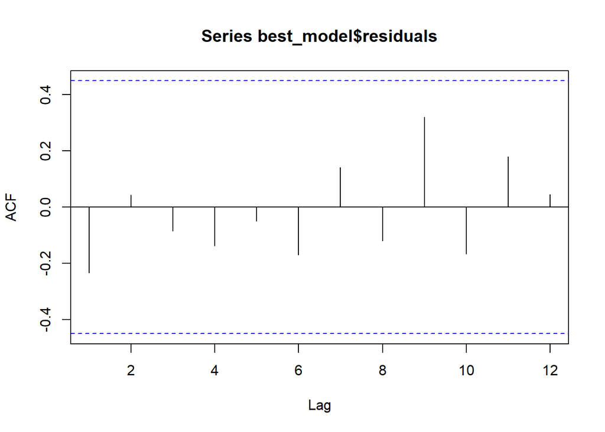

Figure 8: ACF plot for Residuals

```r
acf(best_model$residuals)
```

```r
shapiro.test(best_model$residuals)
```

```
##
##  Shapiro-Wilk normality test
##
## data:  best_model$residuals
## W = 0.96728, p-value = 0.7211
```

Since p-value > 0.05 for 95% level of significance, we cannot reject $H_0$ that residuals are normal.

```r
ncvTest(best_model)
```

```
## Non-constant Variance Score Test
## Variance formula: ~ fitted.values
## Chisquare = 1.06388, Df = 1, p = 0.30233
```

The NVC test show that residuals are homoscedastic.

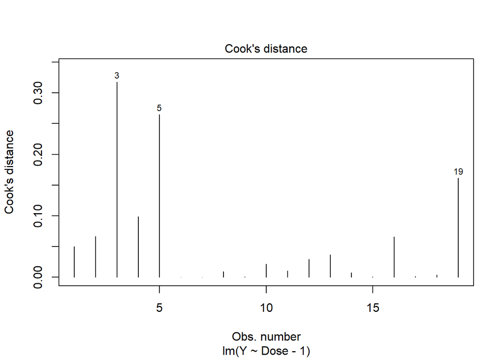

Figure 9: Cook`s distance

```r
plot(best_model, which=4, cook.levels= 4/((n-length(best_model$coefficients)-2)))
```

The Cook’s distance plot show that observation 3, 5 and 19 may be outliers.

Same is reflected in influence plot below.

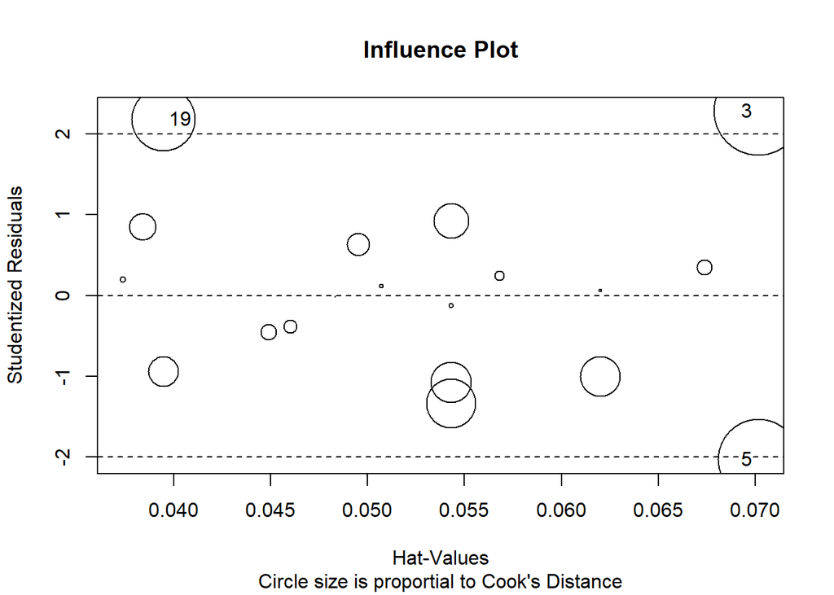

Figure 10: Influence plot

```r
inplot <- influencePlot(best_model, main="Influence Plot", sub="Circle size is proportial to Cook's Distance" )
```

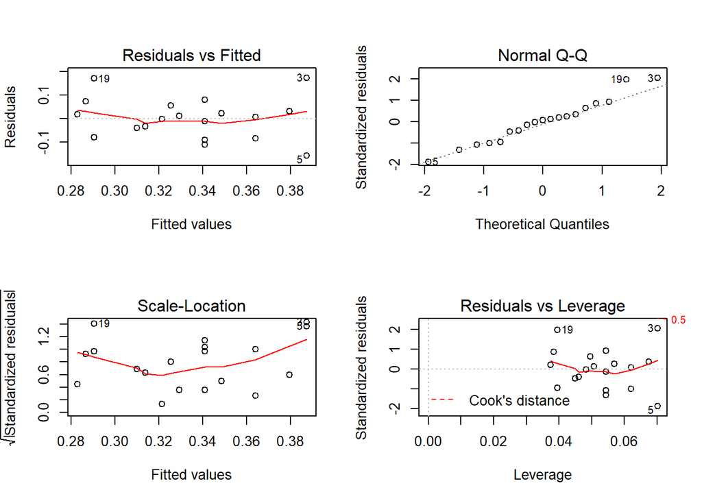

Figure 11: Model diagonistic plots

```r
par(mfrow=c(2,2))
plot(best_model)
```

Referring to Residual vs Fitted plot, the following observations can be made:

- The residuals are spread randomly around the 0 line indicating that the relationship is linear.
- The residuals form an approximate horizontal band around the 0 line indicating homogeneity of error variance.
- Observations 19, 3 and 5 are outliers.

Overall the diagonistics are good for the model selected via backward elimination.

# Sales Data: Crest Toothpaste

## Insights

The dataset contains the below fields:

- Crest Sales
- Budget
- Ratio
- Disposable Income

The data is loaded into the dataframe.

```r
df2 <- data.frame(numeric(), numeric(), numeric(), numeric())
df2 <- rbind(df2, c(105000,16300,1.25,547.9))
df2 <- rbind(df2, c(105000,15800,1.34,593.4))
df2 <- rbind(df2, c(121600,16000,1.22,638.9))
df2 <- rbind(df2, c(113750,14200,1.00,695.3))
df2 <- rbind(df2, c(113750,15000,1.15,751.8))
df2 <- rbind(df2, c(128925,14000,1.13,810.3))
df2 <- rbind(df2, c(142500,15400,1.05,914.5))
df2 <- rbind(df2, c(126000,18250,1.27,998.3))
df2 <- rbind(df2, c(162000,17300,1.07,1096.1))
df2 <- rbind(df2, c(191625,23000,1.17,1194.4))
df2 <- rbind(df2, c(189000,19300,1.07,1311.5))
df2 <- rbind(df2, c(210000,23056,1.54,1462.9))
df2 <- rbind(df2, c(224250,26000,1.59,1641.7))
df2 <- rbind(df2, c(245000,28000,1.56,1821.7))
colnames(df2) <- c("crest_sales", "crest_budget", "ratio", "disposable_income")
head(df2, 5) %>%
  kable(., caption = "Table 6: First five records from the Crest Toothpaste Sales dataset") %>%
  kable_styling()
```

Table 6: First five records from the Crest Toothpaste Sales dataset

| crest_sales | crest_budget | ratio | disposable_income |
| --- | --- | --- | --- |
| 105000 | 16300 | 1.25 | 547.9 |
| 105000 | 15800 | 1.34 | 593.4 |
| 121600 | 16000 | 1.22 | 638.9 |
| 113750 | 14200 | 1.00 | 695.3 |
| 113750 | 15000 | 1.15 | 751.8 |

The data is plotted below. The plot below provides the below details.

- Correlation coefficient (r)
- Histogram with density estimation and rug plot.
- Scatter plot with fitted line

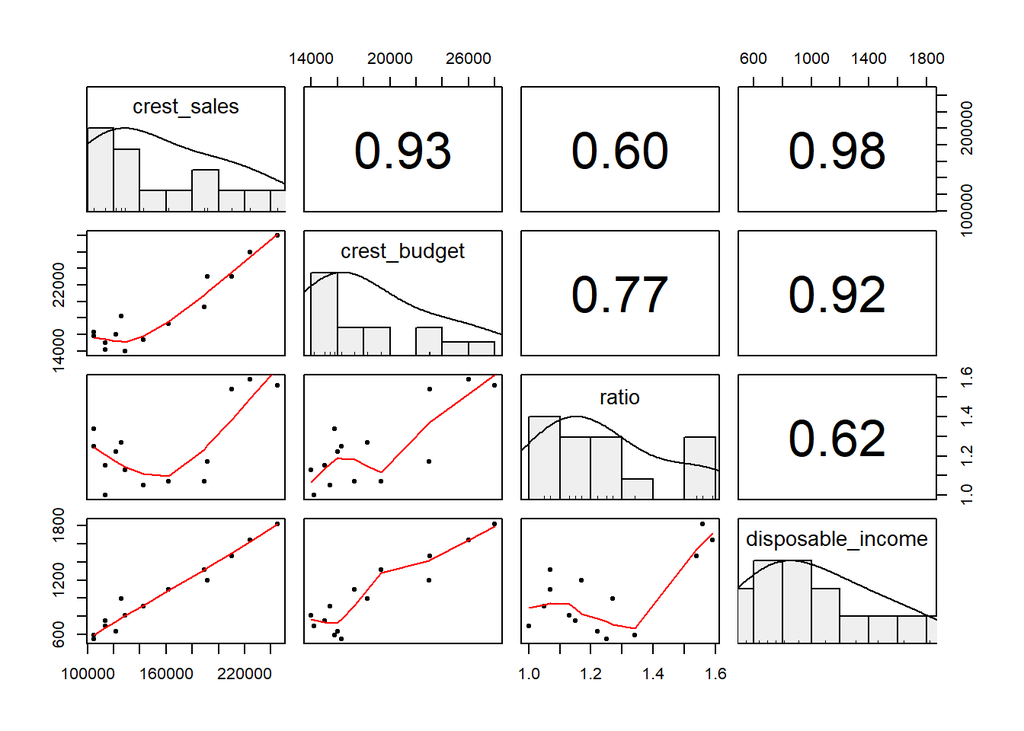

Figure 12: Scatter matrix plot for the experiment data.

```r
pairs.panels(df2,
             method = "pearson", # correlation method
             hist.col = "#efefef",
             density = TRUE,  # show density plots
             ellipses = FALSE, # show correlation ellipses
             lm = FALSE, cor = TRUE
             )
```

From the plot above, we can infer the following:

- There is very strong correlation between crest_budget and disposable income fields.
- Most of the independent variables appear to have right-skewed distribution.
- There is correlation between ratio and other two atrributes crest_budget and disposable income.

**Since dataset is positively skewed, using square root transformation.**

```r
df2.scaled <- sqrt(df2)
head(df2.scaled) %>%
  kable(., caption = "Table 7: First five records from transformed dataset") %>%
  kable_styling()
```

Table 7: First five records from transformed dataset

| crest_sales | crest_budget | ratio | disposable_income |
| --- | --- | --- | --- |
| 324.0370 | 127.6715 | 1.118034 | 23.40726 |
| 324.0370 | 125.6981 | 1.157584 | 24.35980 |
| 348.7119 | 126.4911 | 1.104536 | 25.27647 |
| 337.2684 | 119.1638 | 1.000000 | 26.36854 |
| 337.2684 | 122.4745 | 1.072380 | 27.41897 |
| 359.0613 | 118.3216 | 1.063015 | 28.46577 |

The tranformed data is plotted below. Some improvement in skewness in dataset is observed.

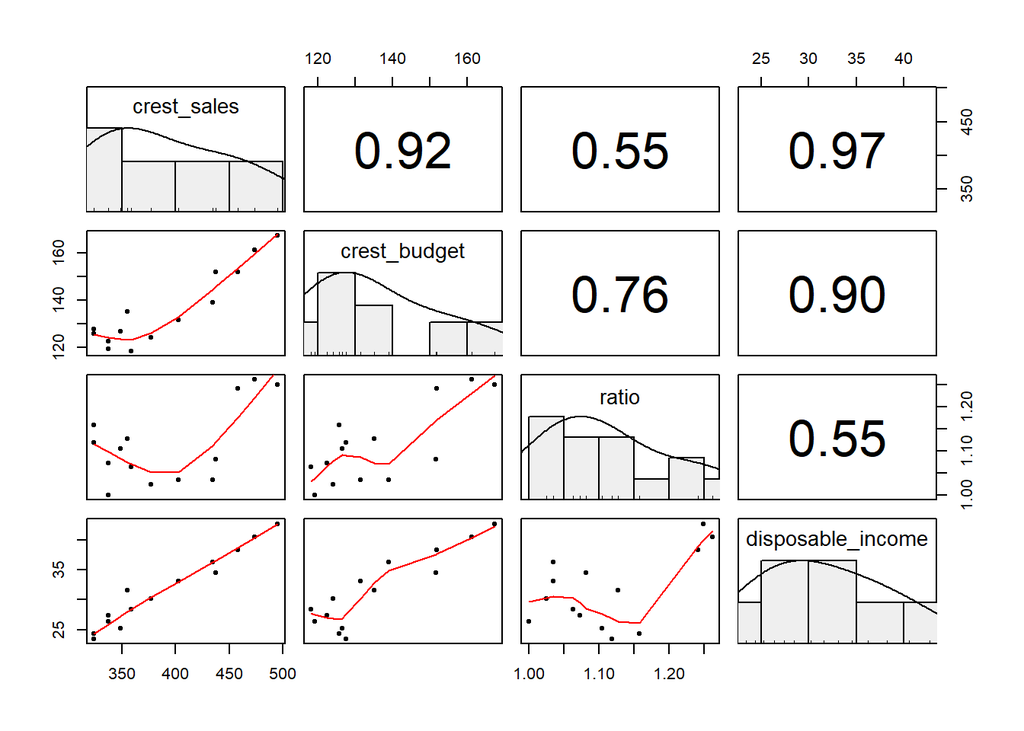

Figure 13: Scatter matrix plot for the experiment data.

```r
pairs.panels(df2.scaled,
             method = "pearson", # correlation method
             hist.col = "#efefef",
             density = TRUE,  # show density plots
             ellipses = FALSE, # show correlation ellipses
             lm = FALSE, cor = TRUE
             )
```

```r
cor(df2.scaled[,2:4], method = c("pearson")) %>%
  kable(., caption = "Table 7: Correlation matrix") %>%
  kable_styling()
```

Table 7: Correlation matrix

|  | crest_budget | ratio | disposable_income |
| --- | --- | --- | --- |
| crest_budget | 1.0000000 | 0.7566346 | 0.8956863 |
| ratio | 0.7566346 | 1.0000000 | 0.5526292 |
| disposable_income | 0.8956863 | 0.5526292 | 1.0000000 |

There is high correlation between crest budget and disposable income. There is also high and +ve correlation between ratio and crest budget. Ratio and disposable income have moderate +ve correlation.

### Multiple Linear regression model

To enable further analysis, a multiple linear regression model is created.

```r
lm.model_2 <- lm(crest_sales~crest_budget+ratio+disposable_income, data = df2.scaled)
summary_lm.model_2 <- summary(lm.model_2)
summary_lm.model_2
```

```
##
## Call:
## lm(formula = crest_sales ~ crest_budget + ratio + disposable_income,
##     data = df2.scaled)
##
## Residuals:
##     Min      1Q  Median      3Q     Max
## -33.087  -1.843   1.228   4.846  13.429
##
## Coefficients:
##                   Estimate Std. Error t value Pr(>|t|)
## (Intercept)         80.266     47.053   1.706 0.118846
## crest_budget         1.375      0.711   1.933 0.081967 .
## ratio              -81.420     70.266  -1.159 0.273486
## disposable_income    6.768      1.447   4.677 0.000871 ***
## ---
## Signif. codes:  0 '***' 0.001 '**' 0.01 '*' 0.05 '.' 0.1 ' ' 1
##
## Residual standard error: 12.92 on 10 degrees of freedom
## Multiple R-squared:  0.9632, Adjusted R-squared:  0.9522
## F-statistic:  87.3 on 3 and 10 DF,  p-value: 1.793e-07
```

*The model is significant at 95% level of significance with p-value 1.793076910^{-7} < 0.05. Although the model is significant, except for the coefficient for disposable income, all other coefficients are insignificant.*

*The Adjusted ${R}^2$ value 0.9521902 is high, which means that 95.22 % observed variation is explained by the linear model.*

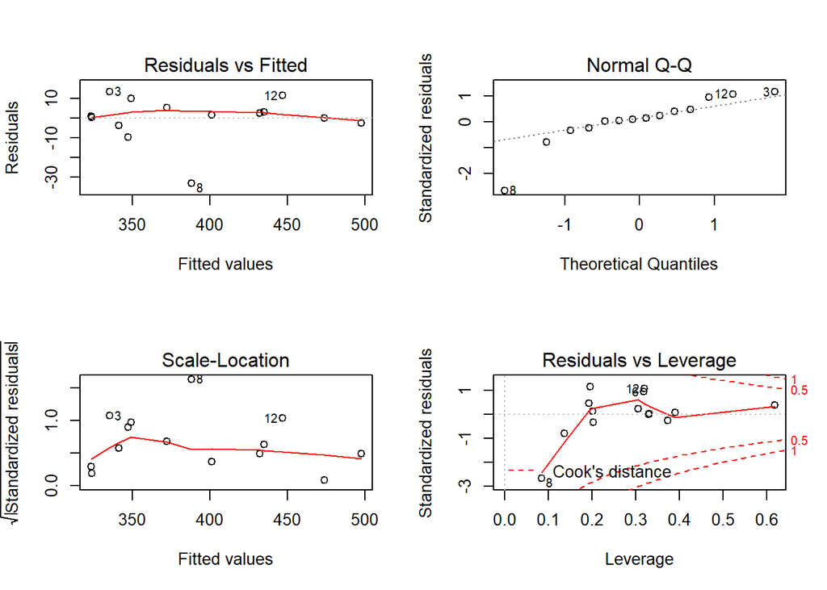

Figure 14: Diagonastic plots for the model

```r
par(mfrow=c(2,2))
plot(lm.model_2)
```

Referring to plots above, the following observations can be made:

- The residuals are spread randomly around the 0 line indicating that the relationship is linear.
- The residuals form an approximate horizontal band around the 0 line indicating homogeneity of error variance.
- Observations 12, 3 and 8 are outliers which may affect the residuals, given it is a very small dataset.
- Most of the points in the Normal Q-Q chart (upper right) fit on the 45 degree line which satisfies normality assumption.
- The points in the Scale - Location graph (bottom left) appear to be random which satisfies Homoscedasticity assumption

```r
anova_2 <- car::Anova(lm.model_2, type="III")
anova_2
```

```
## Anova Table (Type III tests)
##
## Response: crest_sales
##                   Sum Sq Df F value    Pr(>F)
## (Intercept)        485.9  1  2.9099 0.1188464
## crest_budget       624.2  1  3.7382 0.0819667 .
## ratio              224.2  1  1.3427 0.2734859
## disposable_income 3653.0  1 21.8764 0.0008712 ***
## Residuals         1669.9 10
## ---
## Signif. codes:  0 '***' 0.001 '**' 0.01 '*' 0.05 '.' 0.1 ' ' 1
```

*From the ANOVA table, the P-values for the F test statistic not significant for crest budget abd ratio, providing strong evidence for the null hypothesis that ${\beta}_i$ = 0*

*Further the adjusted ${R}^2$ value 0.9521902 is high, which means that 95.22 % observed variation is explained by the linear model.*

## Importance of the variables

Based on the regression model with all predictors, we know that **disposable income is significant**, which suggest that disposable income is important for regression model. *Even crest budget variable is significant at the 90% level of significance*.

Further, relative importance of the variables is generated below.

```r
cl <- calc.relimp(lm.model_2,type=c("lmg","last","first","pratt"),
   rela=TRUE)
cl
```

```
## Response variable: crest_sales
## Total response variance: 3492.703
## Analysis based on 14 observations
##
## 3 Regressors:
## crest_budget ratio disposable_income
## Proportion of variance explained by model: 96.32%
## Metrics are normalized to sum to 100% (rela=TRUE).
##
## Relative importance metrics:
##
##                         lmg       last     first       pratt
## crest_budget      0.3959344 0.13867090 0.4001894  0.35370131
## ratio             0.1154876 0.04980742 0.1462083 -0.06836446
## disposable_income 0.4885780 0.81152168 0.4536023  0.71466315
##
## Average coefficients for different model sizes:
##
##                           1X         2Xs        3Xs
## crest_budget        3.378759    2.540949   1.374642
## ratio             378.277766 -104.153627 -81.419877
## disposable_income   9.331797    8.354391   6.767879
```

```r
boot <- boot.relimp(lm.model_2, b = 14, type = c("lmg",
  "last", "first", "pratt"), rank = TRUE,
  diff = TRUE, rela = TRUE)
# booteval.relimp(boot) # print result
```

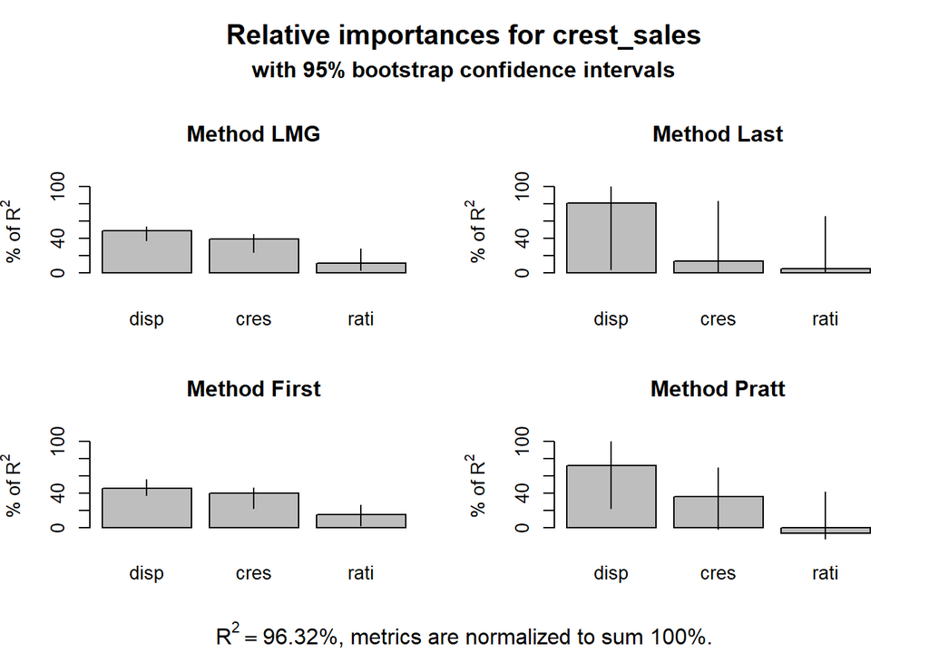

Figure 15: Relative importance of variables

```r
plot(booteval.relimp(boot,sort=TRUE))
```

Based on the output above, the relative importantce of variables is:

- disposable income
- crest budget
- ratio

## Residuals check and assumptions for linear regression

In regression the following assumptions are made about residuals:

- The residuals have normal distribution.
- have mean zero.
- have same but unknown variance (homoscedasticity).
- are independent of each other (independent).
- have no autocorrelation
- $(X^TX)^{-1}X^TX = I$

and

${\sum_{i=1}^n}e_i = 0$

${\sum_{i=1}^n}y_i$ = ${\sum_{i=1}^n}{\hat{y}_i}$

Below given are the calculations that will be used for checking some of the assumptions

```r
n2 <- nrow(df2.scaled)
nr2 <- ncol(df2.scaled) - 1
p2 <- length(coef(lm.model_2))
X_2 <- as.matrix(cbind(rep(1, n2), df2.scaled$crest_budget, df2.scaled$ratio, df2.scaled$disposable_income))
y_2 <- df2.scaled$crest_sales
C_2 <- solve(t(X_2) %*% X_2) # design matrix

beta_hat2 <- solve(t(X_2) %*% X_2) %*% t(X_2) %*% y_2
coefs2 <- as.vector(beta_hat2[,1])
y_hat2 <- X_2 %*% solve(t(X_2) %*% X_2) %*% t(X_2) %*% y_2
e2 <- y_2 - y_hat2
sigma2 <- sqrt(t(e2) %*% e2 / (n2 - p2))
```

Checking the conditions

```r
sum_residuals <- round(sum(e2),8)
sum_y <- sum(y_2)
sum_yhat2 <- sum(y_hat2)
iden <- round((solve(C_2) %*% C_2),8)
```

${\sum_{i=1}^n}e_i$ = 0

${\sum_{i=1}^n}y_i$ = 5464.6068513

${\sum_{i=1}^n}{\hat{y}_i}$ = 5464.6068513

$(X^TX)^{-1}X^TX$ = [1, 0, 0, 0, 0, 1, 0, 0, 0, 0, 1, 0, 0, 0, 0, 1]

Based on the calculations above, the following conditions are true:

${\sum_{i=1}^n}e_i$ = 0 **TRUE**

${\sum_{i=1}^n}y_i$ = ${\sum_{i=1}^n}{\hat{y}_i}$ **TRUE**

$(X^TX)^{-1}X^TX$ = ${I}$ **TRUE**

### Enhanced regression diagnostics

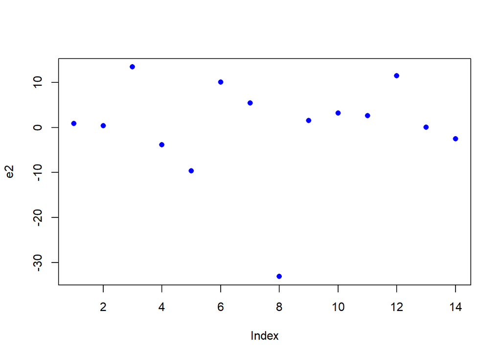

Figure 16: Scatter plot for residuals

```r
plot(e2, pch=16, col="blue")
```

*The above scatter plot show that residuals are independent as there is no pattern in the spread of the residuals.*

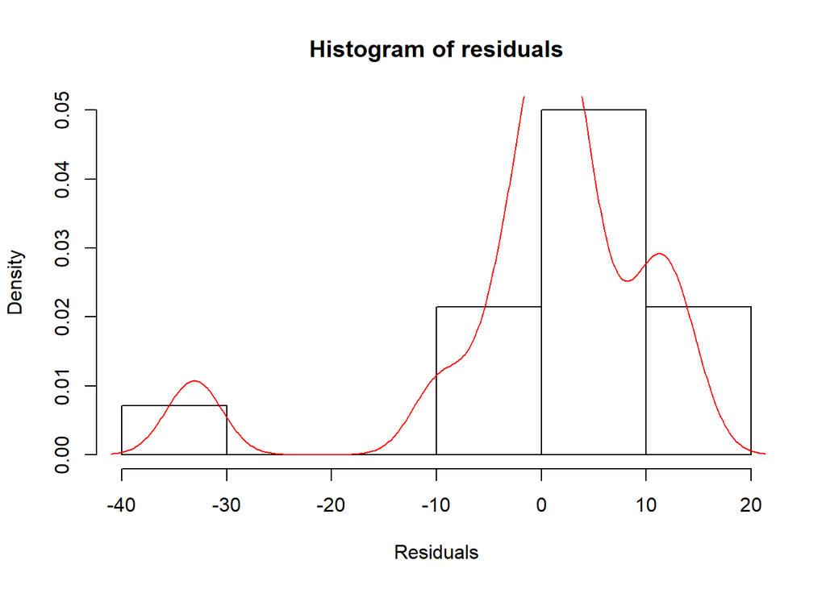

Figure 17: Histogram of residuals

```r
hist(lm.model_2$residuals,probability=T, main="Histogram of residuals",xlab="Residuals")
lines(density(lm.model_2$residuals),col=2)
```

Looking at the histogram for residuals, it seems like residuals are not normal.

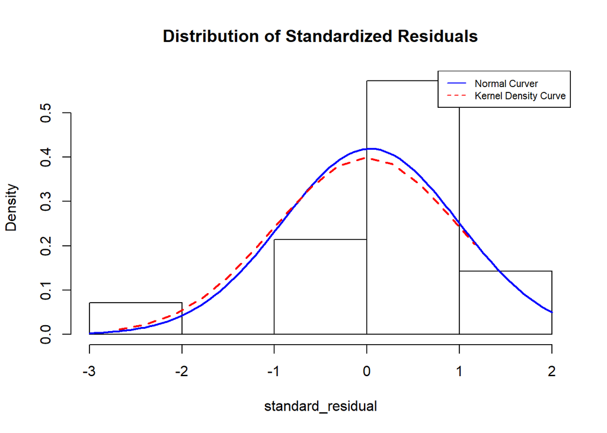

Figure 18: Standardized residuals plot for residuals

```r
standard_residual <- rstandard(lm.model_2)
hist(standard_residual, freq=FALSE,
main="Distribution of Standardized Residuals")
xp<-seq(min(standard_residual),max(standard_residual),length=n2)
yp<-dnorm(xp)
curve(dnorm(x, #superimposes a normal curve created using the dnorm() function
               mean = mean(standard_residual), #mean of the normal distribution
               sd = sd(standard_residual)), #sd of the normal distribution
         add = T, #superimposes the curve
         col = "blue", #color of the curve
         lwd = 2)
lines(xp, yp,col = "red", #color of the curve
         lwd = 2, #line width
         lty = 2)
legend("topright", #adds legend to the top right of the plot
          legend = c("Normal Curver", "Kernel Density Curve"), #provides a vector with legend labels
          lty = 1:2, #provides the line types for the legend (normal, dashed)
          col = c("blue", "red"), #colors of the legend
          cex = 0.7)
```

*The histogram shows that residuals show that standardized residuals may be normal.*

Same is reflected in the qq plot below, where most of the points fall on the line. Observations 3 and 8 are the ouliers.

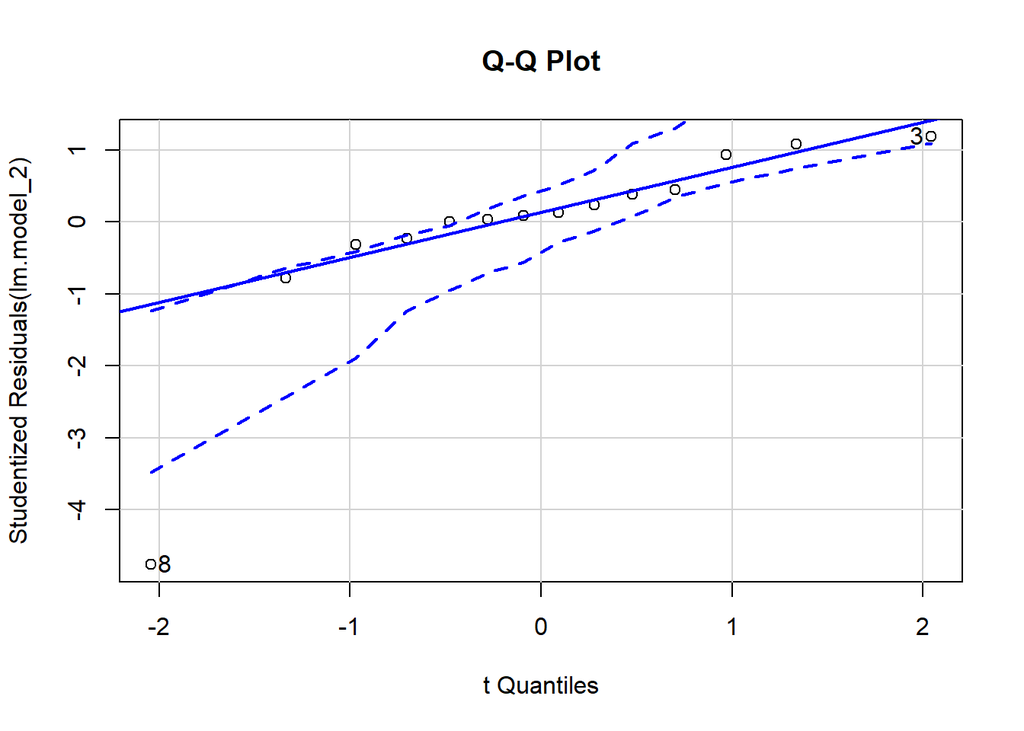

Figure 19: QQ plot for residuals

```r
qq <- qqPlot(lm.model_2,simulate = T, main = "Q-Q Plot") #simulate = T produces a 95% confidence envelope using a parametric bootstrap
```

```r
shapiro.test(lm.model_2$residuals)
```

```
##
##  Shapiro-Wilk normality test
##
## data:  lm.model_2$residuals
## W = 0.81149, p-value = 0.006947
```

*Since p-value < 0.05 for 95% level of significance, we reject $H_0$ that residuals are normal.* *The normality assumption seem to fail for the residuals.*

**Independence of errors**

```r
durbinWatsonTest(lm.model_2)
```

```
##  lag Autocorrelation D-W Statistic p-value
##    1       -0.142766      2.281378    0.93
##  Alternative hypothesis: rho != 0
```

The same is reflected in the ACF plot below.

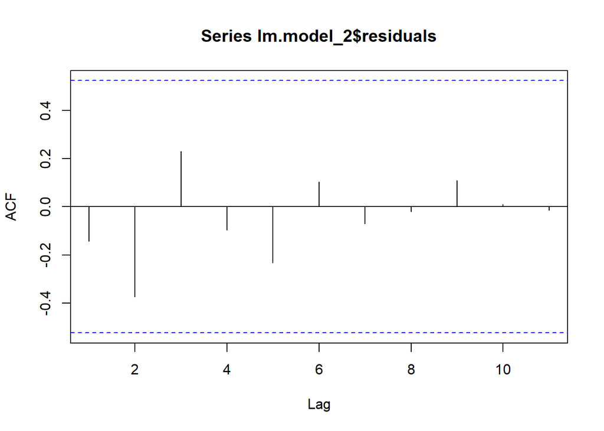

Figure 20: ACF plot for Residuals

```r
acf(lm.model_2$residuals)
```

**Linearity**

A check for evidence of nonlinearity in the relationship between the dependent variable and the independent variables by using component plus residual plots.

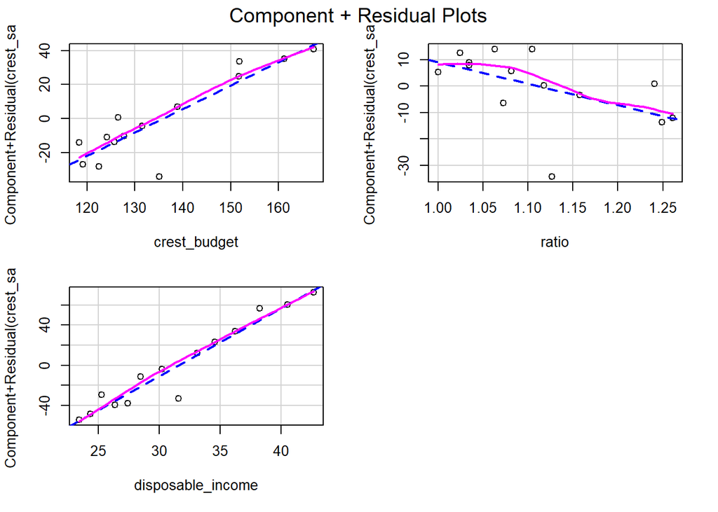

Figure 21: Component plus residual plots

```r
crPlots(lm.model_2)
```

**Homoscedasticity**

```r
ncvTest(lm.model_2)
```

```
## Non-constant Variance Score Test
## Variance formula: ~ fitted.values
## Chisquare = 0.1378853, Df = 1, p = 0.71039
```

The score test is nonsignificant (p = 0.71039) which means that the constant variance assumption holds. The same is reflected in the spread-level plot below.

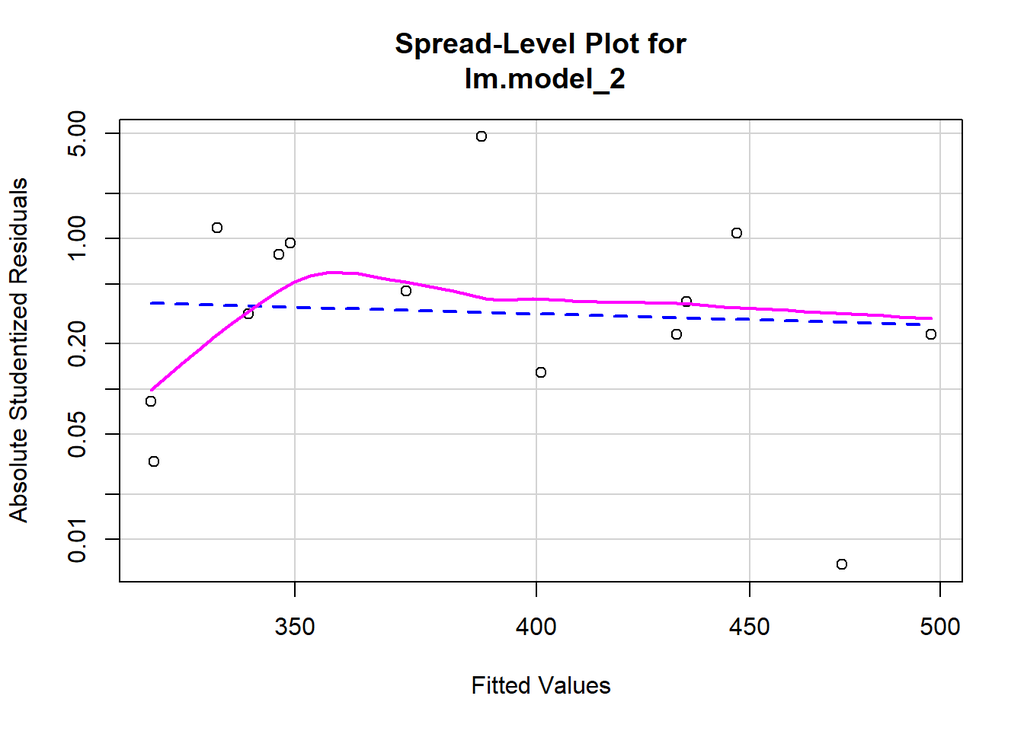

Figure 22: Spread level plot

```
##
## Suggested power transformation:  1.765939
```

```r
spreadLevelPlot(lm.model_2)
```

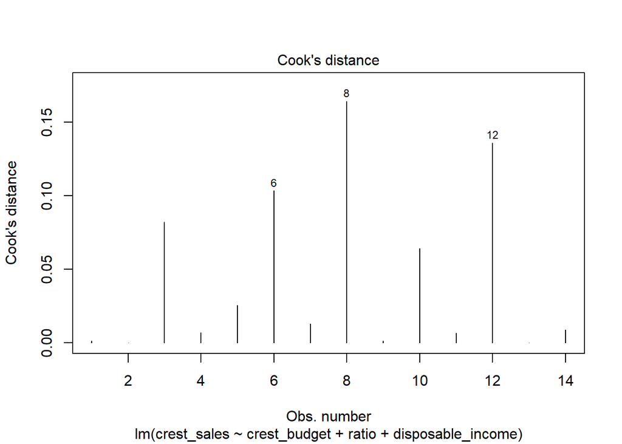

Figure 23: Cook`s distance

```r
plot(lm.model_2, which=4, cook.levels= 4/((n-length(lm.model_2$coefficients)-2)))
```

Same is reflected in influence plot below.

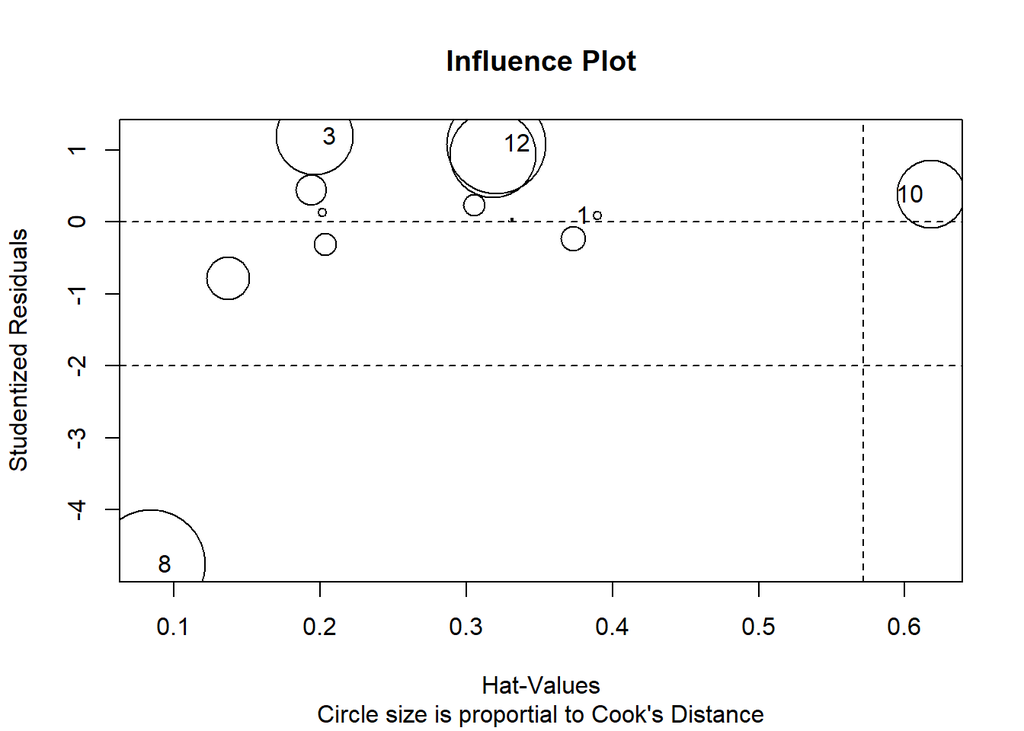

Figure 24: Influence plot

```r
inplot <- influencePlot(lm.model_2, main="Influence Plot", sub="Circle size is proportial to Cook's Distance" )
```

**Added variable plots help identify how influential observations affect the model**

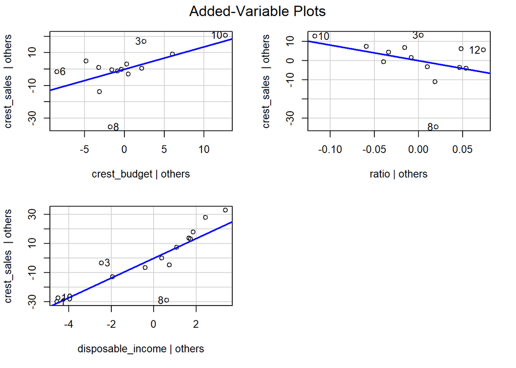

Figure 25: Added variable plots

```r
avPlots(lm.model_2,
        ask = F)
```

### Result from Residual Analysis

Based on the diagonistic above

- The normality assumption seem to fail for the residuals.
- There are some influencial outlier in the data set
- All other assumptions hold true.

## Correlation and Variance of inflation factor

### Correlation

Given below is the correlation matrix for independent variables and a correlation plot.

```r
cor(df2.scaled[,2:4], method = c("pearson")) %>%
  kable(., caption = "Table 8: Correlation matrix") %>%
  kable_styling()
```

Table 8: Correlation matrix

|  | crest_budget | ratio | disposable_income |
| --- | --- | --- | --- |
| crest_budget | 1.0000000 | 0.7566346 | 0.8956863 |
| ratio | 0.7566346 | 1.0000000 | 0.5526292 |
| disposable_income | 0.8956863 | 0.5526292 | 1.0000000 |

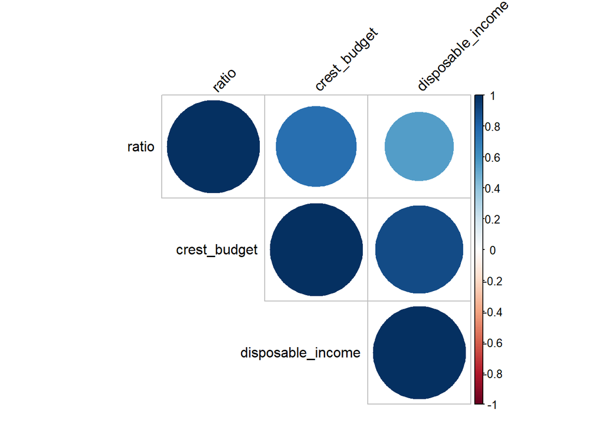

Figure 26: Correlation plot

```r
corrplot::corrplot(cor(df2.scaled[,2:4], method = c("pearson")), type = "upper", order = "hclust",
         tl.col = "black", tl.srt = 45)
```

*From the correlation matrix and plot we can see that the predictors are highly postively correlated which point to presence of multicollinearity.*

### Variance of inflation factor

Given below is VIF for the regression model.

```r
car::vif(lm.model_2) %>%
  kable(., caption = "Table 9: Variance of inflation factor") %>%
  kable_styling()
```

Table 9: Variance of inflation factor

|  | x |
| --- | --- |
| crest_budget | 10.082356 |
| ratio | 2.870347 |
| disposable_income | 6.205360 |

```r
sqrt(car::vif(lm.model_2)) > 2.24
```

```
##      crest_budget             ratio disposable_income
##              TRUE             FALSE              TRUE
```

*We see that VIF is greater than 5 for crest budget and income, which indicates **multicollinearity** present in the model due crest budget and income.*

### Outlier test

Below given is the outlier test for the model. It is evident from previous analysis and the test below that observation 8 is an outlier.

```r
outlierTest(lm.model_2)
```

```
##    rstudent unadjusted p-value Bonferonni p
## 8 -4.760894          0.0010284     0.014397
```

## Stepwise selection: Selecting the best regression model

In stepwise selection, variables are added to or deleted from a model one at a time, until some stopping criterion is reached:

- forward stepwise regression : predictor variables are added to the model one at a time, stopping when the addition of variables would no longer improve the model.
- backward stepwise regression: start with a model that includes all predictor variables, and predictors are deleted one at a time until removing variables degrades the quality of the model
- Stepwise stepwise regression: Both the forward and backward approaches are combined. A predictor variable may be added to and deleted from a model several times before a final solution is reached.

**regsubsets** function is used to perform the stepwise selections.

Performing exhaustive selection:

```r
leaps_2_ex <- regsubsets(crest_sales~crest_budget+ratio+disposable_income,data=df2.scaled,nbest=10,method=c("exhaustive"))
sum.ex <- summary(leaps_2_ex)
sum.ex
```

```
## Subset selection object
## Call: regsubsets.formula(crest_sales ~ crest_budget + ratio + disposable_income,
##     data = df2.scaled, nbest = 10, method = c("exhaustive"))
## 3 Variables  (and intercept)
##                   Forced in Forced out
## crest_budget          FALSE      FALSE
## ratio                 FALSE      FALSE
## disposable_income     FALSE      FALSE
## 10 subsets of each size up to 3
## Selection Algorithm: exhaustive
##          crest_budget ratio disposable_income
## 1  ( 1 ) " "          " "   "*"
## 1  ( 2 ) "*"          " "   " "
## 1  ( 3 ) " "          "*"   " "
## 2  ( 1 ) "*"          " "   "*"
## 2  ( 2 ) " "          "*"   "*"
## 2  ( 3 ) "*"          "*"   " "
## 3  ( 1 ) "*"          "*"   "*"
```

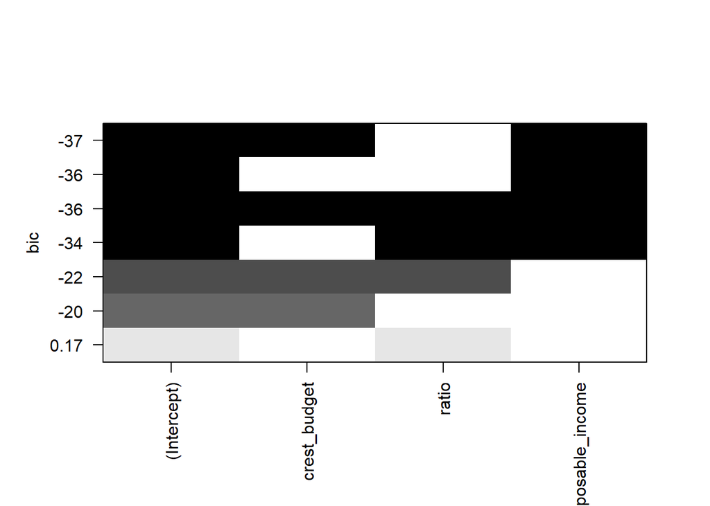

Figure 27: Exhaustive stepwise regsubsets plot

```r
plot(leaps_2_ex,scale='bic')
```

*From the exhaustive selection method, when results are sorted via bic, the best model is with predictors **budget and disposable income**. Second best model is with single predictor **disposable income**.*

```r
leaps_2_bk <- regsubsets(crest_sales~crest_budget+ratio+disposable_income,data=df2.scaled,nbest=10,method=c("backward"))
sum.bk <- summary(leaps_2_bk)
sum.bk
```

```
## Subset selection object
## Call: regsubsets.formula(crest_sales ~ crest_budget + ratio + disposable_income,
##     data = df2.scaled, nbest = 10, method = c("backward"))
## 3 Variables  (and intercept)
##                   Forced in Forced out
## crest_budget          FALSE      FALSE
## ratio                 FALSE      FALSE
## disposable_income     FALSE      FALSE
## 10 subsets of each size up to 3
## Selection Algorithm: backward
##          crest_budget ratio disposable_income
## 1  ( 1 ) " "          " "   "*"
## 1  ( 2 ) "*"          " "   " "
## 2  ( 1 ) "*"          " "   "*"
## 2  ( 2 ) "*"          "*"   " "
## 3  ( 1 ) "*"          "*"   "*"
```

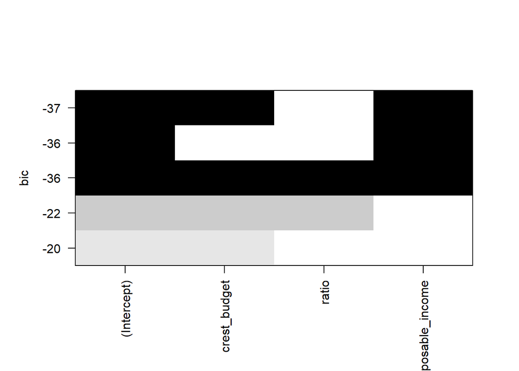

Figure 28: Backward stepwise regsubsets plot

```r
plot(leaps_2_bk,scale='bic')
```

*From the backward selection method, when results are sorted via bic, the best model is with predictors **budget and disposable income**. Second best model is with single predictor **disposable income**.*

```r
leaps_2_fw <- regsubsets(crest_sales~crest_budget+ratio+disposable_income,data=df2.scaled,nbest=10,method=c("forward"))
sum.fw <- summary(leaps_2_fw)
sum.fw
```

```
## Subset selection object
## Call: regsubsets.formula(crest_sales ~ crest_budget + ratio + disposable_income,
##     data = df2.scaled, nbest = 10, method = c("forward"))
## 3 Variables  (and intercept)
##                   Forced in Forced out
## crest_budget          FALSE      FALSE
## ratio                 FALSE      FALSE
## disposable_income     FALSE      FALSE
## 10 subsets of each size up to 3
## Selection Algorithm: forward
##          crest_budget ratio disposable_income
## 1  ( 1 ) " "          " "   "*"
## 1  ( 2 ) "*"          " "   " "
## 1  ( 3 ) " "          "*"   " "
## 2  ( 1 ) "*"          " "   "*"
## 2  ( 2 ) " "          "*"   "*"
## 2  ( 3 ) "*"          "*"   " "
## 3  ( 1 ) "*"          "*"   "*"
```

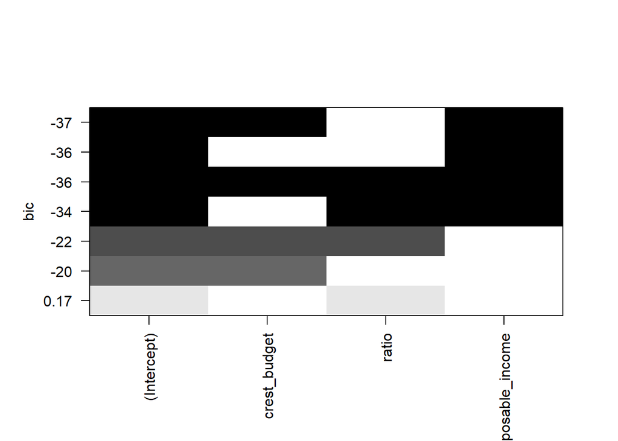

Figure 29: Forward stepwise regsubsets plot

```r
plot(leaps_2_fw,scale='bic')
```

*From the forward selection method, when results are sorted via bic, the best model is with predictors **budget and disposable income**. Second best model is with single predictor **disposable income**.*

```r
leaps_2_sq <- regsubsets(crest_sales~crest_budget+ratio+disposable_income,data=df2.scaled,nbest=10,method=c("seqrep"))
sum.sq <- summary(leaps_2_sq)
sum.sq
```

```
## Subset selection object
## Call: regsubsets.formula(crest_sales ~ crest_budget + ratio + disposable_income,
##     data = df2.scaled, nbest = 10, method = c("seqrep"))
## 3 Variables  (and intercept)
##                   Forced in Forced out
## crest_budget          FALSE      FALSE
## ratio                 FALSE      FALSE
## disposable_income     FALSE      FALSE
## 10 subsets of each size up to 3
## Selection Algorithm: 'sequential replacement'
##          crest_budget ratio disposable_income
## 1  ( 1 ) " "          " "   "*"
## 1  ( 2 ) "*"          " "   " "
## 1  ( 3 ) " "          "*"   " "
## 2  ( 1 ) "*"          "*"   " "
## 3  ( 1 ) "*"          "*"   "*"
```

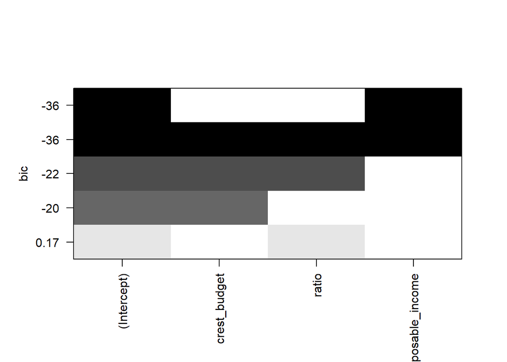

Figure 30: sequential replacement stepwise regsubsets plot

```r
plot(leaps_2_sq,scale='bic')
```

*From the sequential replacement selection method, when results are sorted via bic, the best model is with predictor **disposable income**. Second best model is with all predictors.*

Given below is the another method for performing stepwise selection.

**stepAIC()** function in the MASS package is used to perform the selection.

```r
step_2 <- stepAIC(lm.model_2, direction="both")
```

```
## Start:  AIC=74.94
## crest_sales ~ crest_budget + ratio + disposable_income
##
##                     Df Sum of Sq    RSS    AIC
## - ratio              1     224.2 1894.1 74.704
## <none>                           1669.9 74.940
## - crest_budget       1     624.2 2294.1 77.386
## - disposable_income  1    3653.0 5322.9 89.170
##
## Step:  AIC=74.7
## crest_sales ~ crest_budget + disposable_income
##
##                     Df Sum of Sq    RSS    AIC
## <none>                           1894.1 74.704
## + ratio              1     224.2 1669.9 74.940
## - crest_budget       1     414.2 2308.2 75.473
## - disposable_income  1    5489.0 7383.0 91.750
```

```r
summary(step_2)
```

```
##
## Call:
## lm(formula = crest_sales ~ crest_budget + disposable_income,
##     data = df2.scaled)
##
## Residuals:
##     Min      1Q  Median      3Q     Max
## -34.720  -3.593   2.938   6.537  13.176
##
## Coefficients:
##                   Estimate Std. Error t value Pr(>|t|)
## (Intercept)        45.9276    37.1137   1.237  0.24167
## crest_budget        0.7930     0.5113   1.551  0.14919
## disposable_income   7.4892     1.3264   5.646  0.00015 ***
## ---
## Signif. codes:  0 '***' 0.001 '**' 0.01 '*' 0.05 '.' 0.1 ' ' 1
##
## Residual standard error: 13.12 on 11 degrees of freedom
## Multiple R-squared:  0.9583, Adjusted R-squared:  0.9507
## F-statistic: 126.3 on 2 and 11 DF,  p-value: 2.58e-08
```

```r
step_2$anova
```

```
## Stepwise Model Path
## Analysis of Deviance Table
##
## Initial Model:
## crest_sales ~ crest_budget + ratio + disposable_income
##
## Final Model:
## crest_sales ~ crest_budget + disposable_income
##
##
##      Step Df Deviance Resid. Df Resid. Dev      AIC
## 1                            10   1669.853 74.94007
## 2 - ratio  1 224.2062        11   1894.059 74.70388
```

Based on the stepAIC function, the best model is with predictors crest budget and disposable income.

Using anova to determine the best model between model with single predictor disposable income and model with predictors crest budget and disposable income.

```r
anova(lm(crest_sales~disposable_income,data=df2.scaled), lm(crest_sales~crest_budget+disposable_income,data=df2.scaled))
```

```
## Analysis of Variance Table
##
## Model 1: crest_sales ~ disposable_income
## Model 2: crest_sales ~ crest_budget + disposable_income
##   Res.Df    RSS Df Sum of Sq      F Pr(>F)
## 1     12 2308.2
## 2     11 1894.1  1    414.18 2.4054 0.1492
```

When using anova to compare the models, it is observed that adding crest budget predictor to model with doesnt provide much difference in terms of regression model.

There is correlation between crest budget and disposable income, hence the model selected is the one with single predictor disposable income.

```r
best_model2 <- lm(crest_sales~disposable_income,data=df2.scaled)
```

Given below is the diagonistic for the model selected above.

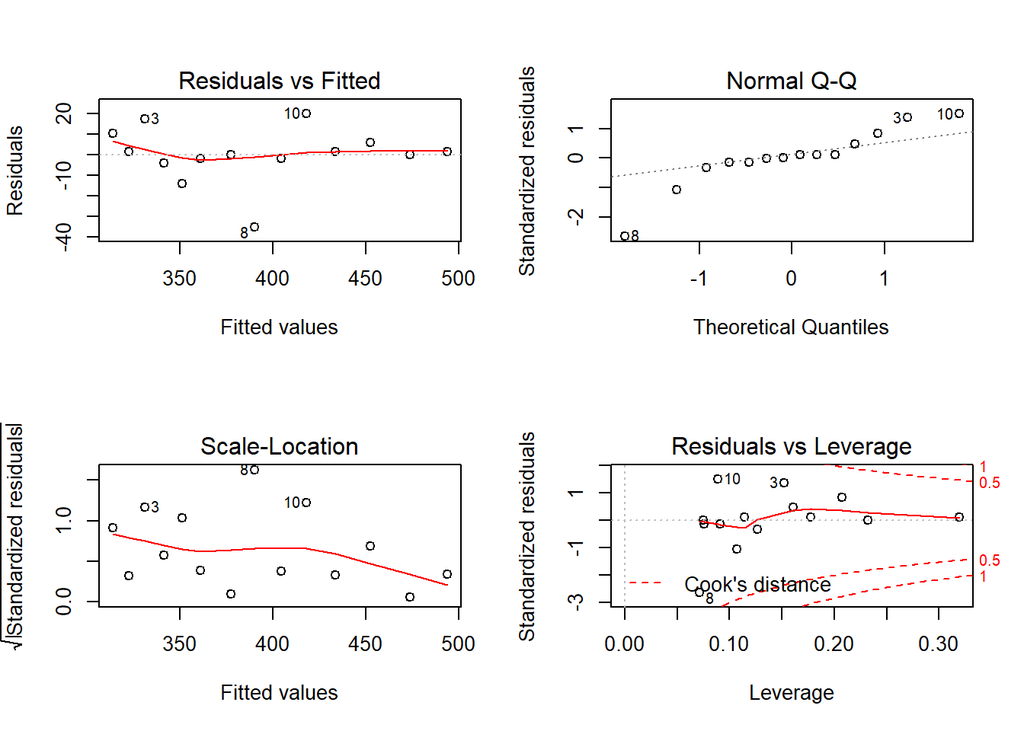

Figure 31: Model diagonistic plots

```r
par(mfrow=c(2,2))
plot(best_model2)
```

Referring diagonistic plots above, the following observations can be made:

- The residuals are spread randomly around the 0 line indicating that the relationship is linear.
- The residuals form an approximate horizontal band around the 0 line indicating homogeneity of error variance.
- Observations 10, 3 and 8 may be outliers.

Overall the diagonistics are good for the model selected above.

# References

- https://www.statmethods.net/stats/regression.html
- http://www.sthda.com/english/articles/37-model-selection-essentials-in-r/154-stepwise-regression-essentials-in-r/
- https://courses.washington.edu/b515/l5.pdf
- https://www.calvin.edu/~rpruim/courses/s341/S17/from-class/MathinRmd.html
- http://www.ams.sunysb.edu/~zhu/ams571/Regression.pdf
- https://daviddalpiaz.github.io/appliedstats/multiple-linear-regression.html